# HEART DISEASE PREDICTION

Data Collection: We obtain the medical data for the patients from trusted and authorized sources. This data includes relevant information such as medical records, diagnoses, treatments, and other pertinent details. We prioritize privacy and adhere to strict data protection protocols to ensure the confidentiality of patient information.

Data Preprocessing:we proceed with the crucial step of data preprocessing. This step involves cleaning and preparing the data for further analysis.

Data Split: Once the medical data is obtained, we perform a careful data split. This involves dividing the collected data into two subsets: a 80% training set and a 20% testing set. The training set is used to train machine learning models and algorithms, allowing them to learn patterns and relationships within the data. The testing set is reserved for evaluating the performance and generalization ability of the trained models.

By splitting the data in this manner, we can effectively assess the accuracy and effectiveness of our models while ensuring robustness and reliability in their predictions.

Explanatory Data Analysis (EDA): After preprocessing the data, we delve deeper into its analysis through Exploratory Data Analysis (EDA). EDA involves a comprehensive examination of the data to uncover patterns, relationships, and insights that can guide subsequent modeling and decision-making processes.

Disease Prediction: To predict diseases accurately, we employ a range of machine learning algorithms, leveraging their capabilities to analyze the collected medical data. These algorithms enable us to identify patterns, correlations, and predictive features that contribute to disease prediction.

```python
import numpy as np
import pandas as pd
import matplotlib.pyplot as plt
import pandas as pd
from sklearn.model_selection import train_test_split
from sklearn.linear_model import LogisticRegression
from sklearn.metrics import accuracy_score
from sklearn.preprocessing import OneHotEncoder
import seaborn as sns
from sklearn.metrics import confusion_matrix
```

```python
df = pd.read_csv("C:/Users/Sankung/Downloads/heart.csv")
```

```python
df.head()
```

|  | age | sex | cp | trestbps | chol | fbs | restecg | thalach | exang | oldpeak | slope | ca | thal | target |
| --- | --- | --- | --- | --- | --- | --- | --- | --- | --- | --- | --- | --- | --- | --- |
| 0 | 63 | 1 | 1 | 145 | 233 | 1 | 2 | 150 | 0 | 2.3 | 3 | 0 | fixed | 0 |
| 1 | 67 | 1 | 4 | 160 | 286 | 0 | 2 | 108 | 1 | 1.5 | 2 | 3 | normal | 1 |
| 2 | 67 | 1 | 4 | 120 | 229 | 0 | 2 | 129 | 1 | 2.6 | 2 | 2 | reversible | 0 |
| 3 | 37 | 1 | 3 | 130 | 250 | 0 | 0 | 187 | 0 | 3.5 | 3 | 0 | normal | 0 |
| 4 | 41 | 0 | 2 | 130 | 204 | 0 | 2 | 172 | 0 | 1.4 | 1 | 0 | normal | 0 |

'age': Age of the patient. It represents the age in years of the individual for whom the other measurements are recorded.

'sex': Sex of the patient. It is a binary variable where 1 represents male and 0 represents female.

'cp': Chest pain type. It is a categorical variable with 4 categories representing different types of chest pain experienced by the patient. The categories are typically defined as follows:

Value 1: Typical angina (chest pain related to reduced blood flow to the heart) Value 2: Atypical angina (chest pain not clearly related to heart) Value 3: Non-anginal pain (pain unrelated to heart) Value 4: Asymptomatic (no chest pain)

'trestbps': Resting blood pressure. It represents the resting blood pressure of the patient in millimeters of mercury (mm Hg).

'chol': Serum cholesterol measurement. It denotes the level of cholesterol in the patient's blood serum measured in milligrams per deciliter (mg/dl).

'fbs': Fasting blood sugar. It is a binary variable indicating whether the patient's fasting blood sugar level is greater than 120 mg/dl. A value of 1 represents a fasting blood sugar level greater than 120 mg/dl, and 0 represents a level less than or equal to 120 mg/dl.

'restecg': Resting electrocardiographic results. It represents the results of the resting electrocardiogram, which is a test that measures the electrical activity of the heart at rest. The variable has three possible values:

Value 0: Normal Value 1: Abnormal ST-T wave Value 2: Showing probable or definite left ventricular hypertrophy by Estes' criteria

'thalach': Maximum heart rate achieved. It denotes the maximum heart rate achieved by the patient during exercise.

'exang': Exercise-induced angina. It is a binary variable indicating whether the patient experienced exercise-induced angina during the exercise test. A value of 1 represents the presence of exercise-induced angina, and 0 represents its absence

'oldpeak': ST depression induced by exercise relative to rest. It represents the ST segment depression (measured in millimeters) observed during exercise compared to the resting electrocardiogram.

'slope': The slope of the peak exercise ST segment. It represents the slope of the ST segment during peak exercise, which is an indicator of the rate of change of ST segment depression. The variable has three possible values:

Value 0: Upsloping Value 1: Flat Value 2: Downsloping

'ca': Number of major vessels colored by fluoroscopy. It denotes the number of major blood vessels (0-3) as observed by fluoroscopy. Fluoroscopy is a medical imaging technique that uses X-rays to obtain real-time moving images of the patient's internal structures.

'thal': Thallium stress test result. It represents the results of the thallium stress test, which is a nuclear imaging test used to evaluate blood flow to the heart. The variable has three possible categories:

Value 1: Fixed defect (no blood flow in some part of the heart) Value 2: Normal (normal blood flow) Value 3: Reversible defect (blood flow is observed but not normal)

```python
missing_values_sum = df.isnull().sum()
print(missing_values_sum)
```

```
age         0
sex         0
cp          0
trestbps    0
chol        0
fbs         0
restecg     0
thalach     0
exang       0
oldpeak     0
slope       0
ca          0
thal        0
target      0
dtype: int64
```

```python
df.describe
```

```
<bound method NDFrame.describe of      age  sex  cp  trestbps  chol  fbs  restecg  thalach  exang  oldpeak  \
0     63    1   1       145   233    1        2      150      0      2.3
1     67    1   4       160   286    0        2      108      1      1.5
2     67    1   4       120   229    0        2      129      1      2.6
3     37    1   3       130   250    0        0      187      0      3.5
4     41    0   2       130   204    0        2      172      0      1.4
..   ...  ...  ..       ...   ...  ...      ...      ...    ...      ...
298   52    1   1       118   186    0        2      190      0      0.0
299   43    0   4       132   341    1        2      136      1      3.0
300   65    1   4       135   254    0        2      127      0      2.8
301   48    1   4       130   256    1        2      150      1      0.0
302   63    0   4       150   407    0        2      154      0      4.0

     slope  ca        thal  target
0        3   0       fixed       0
1        2   3      normal       1
2        2   2  reversible       0
3        3   0      normal       0
4        1   0      normal       0
..     ...  ..         ...     ...
298      2   0       fixed       0
299      2   0  reversible       1
300      2   1  reversible       1
301      1   2  reversible       1
302      2   3  reversible       1

[303 rows x 14 columns]>
```

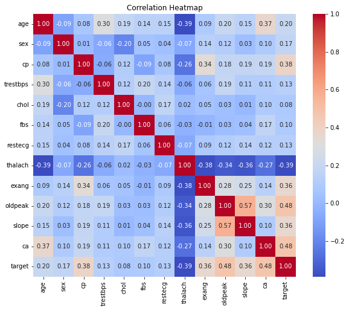

```python
# Calculate correlation matrix
corr_matrix = df.corr()

# Create a correlation heatmap
plt.figure(figsize=(10, 8))
sns.heatmap(corr_matrix, annot=True, cmap='coolwarm', fmt=".2f", square=True)
plt.title('Correlation Heatmap')
plt.show()
```

We don't have a multi-collinearity problem in this data set

```python
# Define the categorical columns
categorical_cols = ['sex', 'cp', 'fbs', 'restecg', 'exang', 'slope', 'ca', 'thal']

# Perform one-hot encoding
df= pd.get_dummies(df, columns=categorical_cols)

# Split the dataset into training and test sets
X = df.drop(columns='target')
```

```python
# Split the dataset into features (X) and target (y)
X = df.drop('target', axis=1)
y = df['target']

# Split the data into train and test sets
X_train, X_test, y_train, y_test = train_test_split(X, y, test_size=0.2, random_state=42)
```

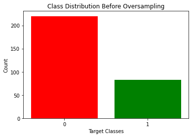

```
Class Counts Before Oversampling:
0    220
1     83
Name: target, dtype: int64
```

```python
from imblearn.over_sampling import SMOTE


# Count the number of samples in each class before oversampling
class_counts_before = df['target'].value_counts()

# Visualize class distribution before oversampling
plt.bar(class_counts_before.index, class_counts_before.values, color=['red', 'green'])
plt.xticks(class_counts_before.index)
plt.xlabel('Target Classes')
plt.ylabel('Count')
plt.title('Class Distribution Before Oversampling')
plt.show()

# Print the class counts before and after oversampling
print("Class Counts Before Oversampling:")
print(class_counts_before)
```

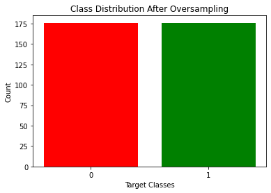

```
Class Counts After Oversampling:
[176 176]
```

```python
# Oversample using SMOTE
smote = SMOTE()
X_train_resampled, y_train_resampled = smote.fit_resample(X_train, y_train)

# Count the number of samples in each class after oversampling
class_counts_after = np.bincount(y_train_resampled)

# Visualize class distribution after oversampling
plt.bar(np.unique(y_train_resampled), class_counts_after, color=['red', 'green'])
plt.xticks(np.unique(y_train_resampled))
plt.xlabel('Target Classes')
plt.ylabel('Count')
plt.title('Class Distribution After Oversampling')
plt.show()

print("\nClass Counts After Oversampling:")
print(class_counts_after)
```

# Logistic Model

```python
# We start with the logistics regression classifier
# Initialize the logistic regression model
model = LogisticRegression()

# Train the model
model.fit(X_train, y_train)

# Make predictions on the test set
y_pred = model.predict(X_test)

# Calculate accuracy
accuracy = accuracy_score(y_test, y_pred)
print('Accuracy:', accuracy)
```

```
Accuracy: 0.8524590163934426
```

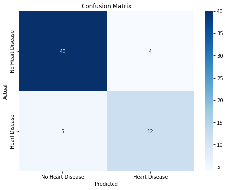

```python
# Create a confusion matrix
confusion_mat = confusion_matrix(y_test, y_pred)

# Define class labels
class_names = ['No Heart Disease', 'Heart Disease']

# Plot the confusion matrix
plt.figure(figsize=(8, 6))
sns.heatmap(confusion_mat, annot=True, fmt='d', cmap='Blues', xticklabels=class_names, yticklabels=class_names)
plt.xlabel('Predicted')
plt.ylabel('Actual')
plt.title('Confusion Matrix')
plt.show()
```

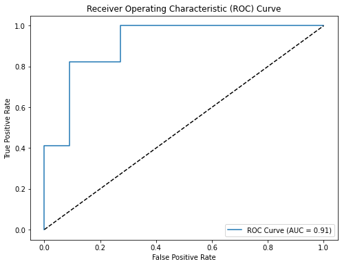

```python
from sklearn.metrics import roc_curve, roc_auc_score

# Calculate predicted probabilities
y_prob = model.predict_proba(X_test)[:, 1]

# Calculate ROC curve
fpr, tpr, thresholds = roc_curve(y_test, y_prob)

# Calculate AUC score
auc = roc_auc_score(y_test, y_prob)

# Plot ROC curve
plt.figure(figsize=(8, 6))
plt.plot(fpr, tpr, label='ROC Curve (AUC = {:.2f})'.format(auc))
plt.plot([0, 1], [0, 1], 'k--')  # Random guessing line
plt.xlabel('False Positive Rate')
plt.ylabel('True Positive Rate')
plt.title('Receiver Operating Characteristic (ROC) Curve')
plt.legend()
plt.show()
```

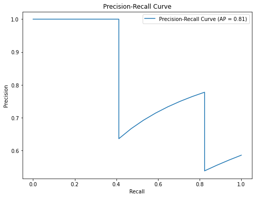

```python
from sklearn.metrics import precision_recall_curve, average_precision_score

# Calculate precision and recall
precision, recall, thresholds = precision_recall_curve(y_test, y_prob)

# Calculate average precision score
avg_precision = average_precision_score(y_test, y_prob)

# Plot precision-recall curve
plt.figure(figsize=(8, 6))
plt.plot(recall, precision, label='Precision-Recall Curve (AP = {:.2f})'.format(avg_precision))
plt.xlabel('Recall')
plt.ylabel('Precision')
plt.title('Precision-Recall Curve')
plt.legend()

plt.show()
```

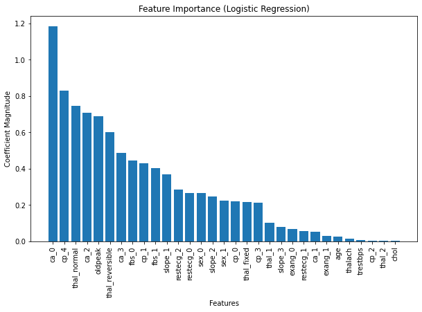

```python
import numpy as np

# Get the absolute values of the coefficients
coefs = np.abs(model.coef_[0])

# Sort the coefficients in descending order
indices = np.argsort(coefs)[::-1]

# Rearrange feature names based on the sorted indices
feature_names = X.columns[indices]

# Plot feature importances
plt.figure(figsize=(10, 6))
plt.bar(range(X.shape[1]), coefs[indices])
plt.xticks(range(X.shape[1]), feature_names, rotation=90)
plt.xlabel('Features')
plt.ylabel('Coefficient Magnitude')
plt.title('Feature Importance (Logistic Regression)')
plt.show()
```

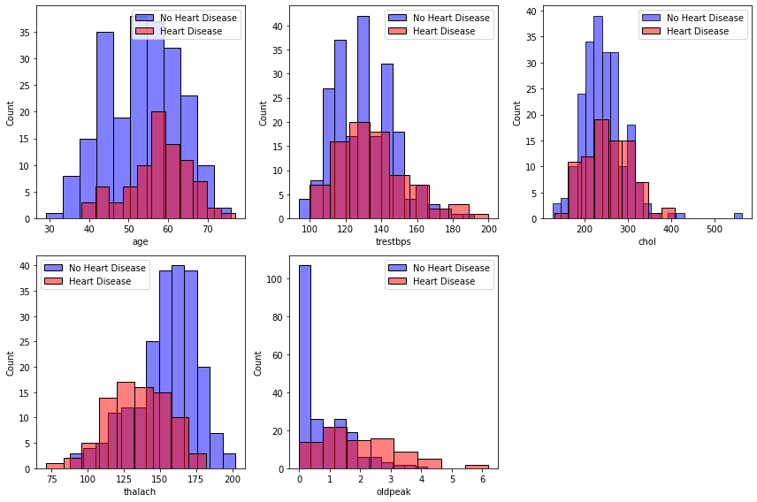

```python
# Select numerical features to plot histograms
numerical_features = ['age', 'trestbps', 'chol', 'thalach', 'oldpeak']

# Plot histograms
plt.figure(figsize=(12, 8))
for i, feature in enumerate(numerical_features):
    plt.subplot(2, 3, i+1)
    sns.histplot(df[feature][df['target'] == 0], label='No Heart Disease', color='blue', alpha=0.5)
    sns.histplot(df[feature][df['target'] == 1], label='Heart Disease', color='red', alpha=0.5)
    plt.xlabel(feature)
    plt.ylabel('Count')
    plt.legend()
plt.tight_layout()
plt.show()
```

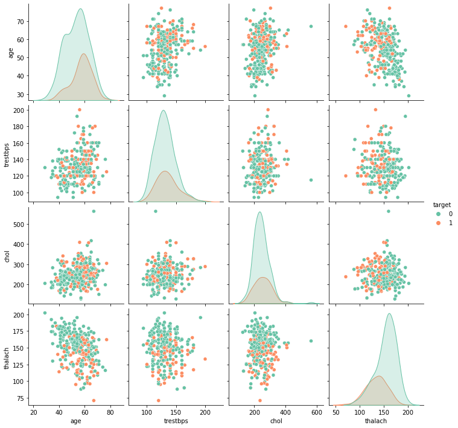

```python
# Select features for pairwise scatter plots
scatter_features = ['age', 'trestbps', 'chol', 'thalach']

# Create pairwise scatter plots
sns.pairplot(data=df, vars=scatter_features, hue='target', palette='Set2')
plt.show()
```

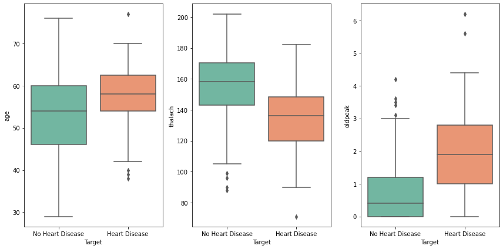

```python
# Select features for box plots
boxplot_features = ['age', 'thalach', 'oldpeak']

# Create box plots
plt.figure(figsize=(12, 6))
for i, feature in enumerate(boxplot_features):
    plt.subplot(1, 3, i+1)
    sns.boxplot(x='target', y=feature, data=df, palette='Set2')
    plt.xlabel('Target')
    plt.ylabel(feature)
    plt.xticks([0, 1], ['No Heart Disease', 'Heart Disease'])
plt.tight_layout()
plt.show()
```

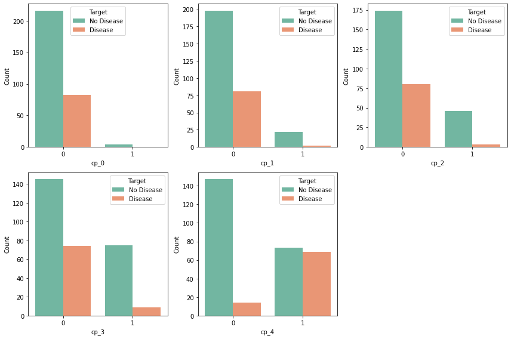

```python
import matplotlib.pyplot as plt
import seaborn as sns

# Select features for count plots
countplot_features = ['cp_0', 'cp_1', 'cp_2', 'cp_3', 'cp_4']

# Create subplots for count plots
plt.figure(figsize=(12, 8))
for i, feature in enumerate(countplot_features):
    plt.subplot(2, 3, i+1)
    sns.countplot(x=feature, hue='target', data=df, palette='Set2')
    plt.xlabel(feature)
    plt.ylabel('Count')
    plt.legend(title='Target', labels=['No Disease', 'Disease'])

plt.tight_layout()
plt.show()
```

# Support Vector Machine

```python
from sklearn.svm import SVC
from sklearn import svm

svc_scores = []
kernels = ['linear', 'poly', 'rbf', 'sigmoid']
for i in range(len(kernels)):
    svc_classifier = SVC(kernel = kernels[i])
    svc_classifier.fit(X_train, y_train)
    svc_scores.append(svc_classifier.score(X_test, y_test))
```

[figure not shown]

```python
from matplotlib.cm import get_cmap

# Sample code for illustration purposes
svc_scores = [0.8, 0.75, 0.82, 0.68]
kernels = ['linear', 'poly', 'rbf', 'sigmoid']
colors = get_cmap('rainbow')(np.linspace(0, 1, len(kernels)))

plt.bar(kernels, svc_scores, color=colors)

for i in range(len(kernels)):
    plt.text(i, svc_scores[i], str(svc_scores[i]), ha='center', va='bottom')

plt.xlabel('Kernel')
plt.ylabel('Accuracy Score')
plt.title('SVC Accuracy Scores for Different Kernels')
plt.ylim(0, 1)  # Set the y-axis limits between 0 and 1

plt.show()
```

```python
# Create an instance of the SVC classifier with RBF kernel
classifier = svm.SVC(kernel='linear')

# Train the classifier on the training data
classifier.fit(X_train, y_train)

# Make predictions on the test data
y_pred = classifier.predict(X_test)

# Evaluate the classifier
accuracy = classifier.score(X_test, y_test)
print("Accuracy:", accuracy)
```

```
Accuracy: 0.8524590163934426
```

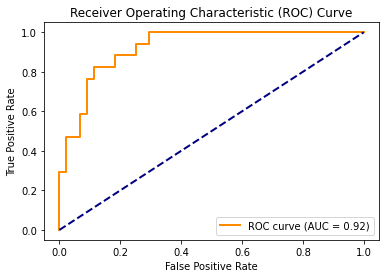

```python
from sklearn.metrics import roc_curve, auc

# Compute the probabilities of the positive class
y_scores = classifier.decision_function(X_test)

# Compute the false positive rate and true positive rate
fpr, tpr, _ = roc_curve(y_test, y_scores)

# Compute the area under the ROC curve
roc_auc = auc(fpr, tpr)

# Plot the ROC curve
plt.plot(fpr, tpr, color='darkorange', lw=2, label='ROC curve (AUC = %0.2f)' % roc_auc)
plt.plot([0, 1], [0, 1], color='navy', lw=2, linestyle='--')

# Set plot labels and title
plt.xlabel('False Positive Rate')
plt.ylabel('True Positive Rate')
plt.title('Receiver Operating Characteristic (ROC) Curve')
plt.legend(loc="lower right")

# Show the plot
plt.show()
```

# Decision Tree Classifier

```python
from sklearn.tree import DecisionTreeClassifier
```

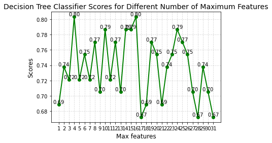

```python
dt_scores = []
for i in range(1, len(X.columns) + 1):
    dt_classifier = DecisionTreeClassifier(max_features=i, random_state=0)
    dt_classifier.fit(X_train, y_train)
    dt_scores.append(dt_classifier.score(X_test, y_test))

plt.plot([i for i in range(1, len(X.columns) + 1)], dt_scores, color='green', marker='o', linestyle='-', linewidth=2)

for i in range(1, len(X.columns) + 1):
    plt.text(i, dt_scores[i-1], f"{dt_scores[i-1]:.2f}", ha='center', va='bottom')

plt.xticks([i for i in range(1, len(X.columns) + 1)])
plt.xlabel('Max features', fontsize=12)
plt.ylabel('Scores', fontsize=12)
plt.title('Decision Tree Classifier Scores for Different Number of Maximum Features', fontsize=14)
plt.grid(True, linestyle='--', alpha=0.5)

plt.show()
```

```python
# Create the Decision Tree classifier with max_features=8
dt_classifier = DecisionTreeClassifier(max_features=4, random_state=0)

# Train the classifier on the training data
dt_classifier.fit(X_train, y_train)

# Evaluate the classifier on the test data
accuracy = dt_classifier.score(X_test, y_test)
print("Accuracy:", accuracy)
```

```
Accuracy: 0.8032786885245902
```

# Random Forest Classifier

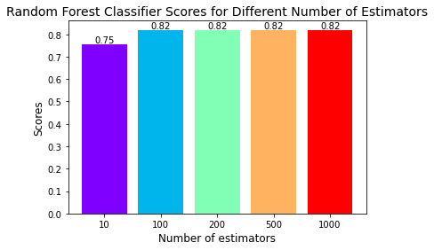

```python
from sklearn.ensemble import RandomForestClassifier

rf_scores = []
estimators = [10, 100, 200, 500, 1000]
for i in estimators:
    rf_classifier = RandomForestClassifier(n_estimators=i, random_state=0)
    rf_classifier.fit(X_train, y_train)
    rf_scores.append(rf_classifier.score(X_test, y_test))

colors = get_cmap('rainbow')(np.linspace(0, 1, len(estimators)))

plt.bar([i for i in range(len(estimators))], rf_scores, color=colors, width=0.8)

for i in range(len(estimators)):
    plt.text(i, rf_scores[i], f"{rf_scores[i]:.2f}", ha='center', va='bottom')

plt.xticks(ticks=[i for i in range(len(estimators))], labels=[str(estimator) for estimator in estimators])
plt.xlabel('Number of estimators', fontsize=12)
plt.ylabel('Scores', fontsize=12)
plt.title('Random Forest Classifier Scores for Different Number of Estimators', fontsize=14)

plt.show()
```

```python
# Create the Random Forest Classifier with 100 estimators
rf_classifier = RandomForestClassifier(n_estimators=100, random_state=0)

# Train the classifier on the training data
rf_classifier.fit(X_train, y_train)

# Evaluate the classifier on the test data
accuracy = rf_classifier.score(X_test, y_test)
print("Accuracy:", accuracy)
```

```
Accuracy: 0.819672131147541
```

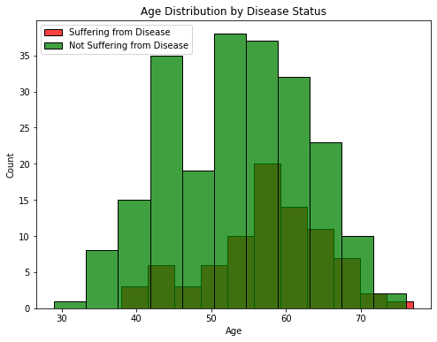

```python
# Separate age data for people with and without the disease
age_disease = df[df['target'] == 1]['age']
age_no_disease = df[df['target'] == 0]['age']

# Plotting the age distribution
plt.figure(figsize=(8, 6))
sns.histplot(age_disease, color='red', label='Suffering from Disease')
sns.histplot(age_no_disease, color='green', label='Not Suffering from Disease')

plt.xlabel('Age')
plt.ylabel('Count')
plt.title('Age Distribution by Disease Status')
plt.legend()
plt.show()
```

# NEURAL NETWORK

```python
import tensorflow as tf

# Define the model
model = tf.keras.Sequential([
    tf.keras.layers.Dense(1, activation='sigmoid', input_shape=(X_train.shape[1],))
])

# Compile the model
model.compile(optimizer='adam',
              loss='binary_crossentropy',
              metrics=['accuracy'])

# Train the model
history = model.fit(X_train, y_train, epochs=1000, verbose=0)

# Evaluate the model on the test set
loss, accuracy = model.evaluate(X_test, y_test)
print("Test Loss:", loss)
print("Test Accuracy:", accuracy)
```

```
Test Loss: 0.35618335008621216
Test Accuracy: 0.8524590134620667
```

# XG BOOST

```python
# Define the XGBoost classifier
model = xgb.XGBClassifier()

# Train the model
eval_set = [(X_train, y_train), (X_test, y_test)]
model.fit(X_train, y_train, eval_set=eval_set, eval_metric='error', verbose=False)

# Make predictions on the test set
predictions = model.predict(X_test)

# Calculate accuracy
accuracy = accuracy_score(y_test, predictions)
print("Test Accuracy:", accuracy)
```

```
Test Accuracy: 0.819672131147541
```

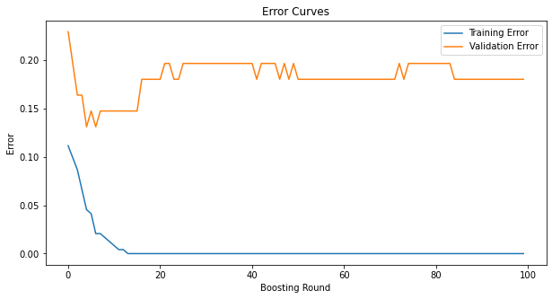

```python
# Get the evaluation results
results = model.evals_result()

# Extract the training and validation metrics
train_error = results['validation_0']['error']
val_error = results['validation_1']['error']

# Visualize the error
plt.figure(figsize=(10, 5))
plt.plot(train_error, label='Training Error')
plt.plot(val_error, label='Validation Error')
plt.title('Error Curves')
plt.xlabel('Boosting Round')
plt.ylabel('Error')
plt.legend()
plt.show()
```